# Project5

Group 5AA_Black-Thenmozhi Boopathy

2025-12-26

# OOS PERFORMANCE COMPETITION - Predict New Observations as Default = Yes or No

In this project, we are using the given scoring data that contains 79243 observations with 36 variables. We are doing the pre processing methods for the scoreing data.For the initial start, just looking at the structure to make a proper execution in predictor variables.

```r
df = read.csv("score.csv", stringsAsFactors = TRUE)
train_df = read.csv("train.csv", stringsAsFactors = TRUE)
train_median <- median(train_df$revol_util, na.rm = TRUE)
str(df)
```

```
## 'data.frame':    79243 obs. of  36 variables:
##  $ ID                    : int  0 1 2 3 4 5 6 7 8 9 ...
##  $ loan_amnt             : int  35000 2600 7000 22250 16000 14000 26650 10000 20000 15000 ...
##  $ term                  : Factor w/ 2 levels " 36 months"," 60 months": 1 1 1 1 2 2 2 1 1 2 ...
##  $ int_rate              : num  13.7 13.7 12.1 21 12.5 ...
##  $ installment           : num  1190.6 88.5 232.9 838.3 359.9 ...
##  $ grade                 : Factor w/ 7 levels "A","B","C","D",..: 3 3 2 5 2 3 6 3 2 4 ...
##  $ sub_grade             : Factor w/ 35 levels "A1","A2","A3",..: 14 11 8 21 10 11 28 12 9 17 ...
##  $ emp_title             : Factor w/ 43586 levels "","  Credit rev specialist",..: 28879 10774 37115 32204 38448 18071 24913 2823 38743 37148 ...
##  $ emp_length            : Factor w/ 12 levels "","< 1 year",..: 4 5 4 4 4 4 11 2 5 8 ...
##  $ home_ownership        : Factor w/ 6 levels "ANY","MORTGAGE",..: 6 2 6 2 6 6 2 6 2 6 ...
##  $ annual_inc            : num  89000 103000 80000 94000 52000 37000 58000 52000 170000 40000 ...
##  $ verification_status   : Factor w/ 3 levels "Not Verified",..: 3 2 1 2 2 2 3 2 3 2 ...
##  $ issue_d               : Factor w/ 114 levels "Apr-2008","Apr-2009",..: 93 54 25 91 64 92 8 8 82 42 ...
##  $ purpose               : Factor w/ 14 levels "car","credit_card",..: 3 3 3 3 2 2 2 3 3 10 ...
```

[output cut: 22 more lines]

# Summary Statistics for numeric Variables

We make sure which variables names are comes under the category of bank_numeric and bank_factor using head(bank_numeric) head(bank_factor).

```r
#Split data into categorical and numeric datasets
bank_numeric <- select_if(df, is.numeric)
bank_factor <- select_if(df, is.factor)
#Ensure dataframes correctly split
head(bank_numeric)
```

```
##   ID loan_amnt int_rate installment annual_inc   dti open_acc pub_rec revol_bal
## 1  0     35000    13.67     1190.62      89000 22.35        8       0     14210
## 2  1      2600    13.68       88.46     103000 26.77       16       0     31492
## 3  2      7000    12.12      232.91      80000 18.86        7       0      2402
## 4  3     22250    21.00      838.28      94000 12.39       10       0     14334
## 5  4     16000    12.49      359.89      52000 19.32       11       0      8434
## 6  5     14000    12.39      314.19      37000 30.49       12       1     13459
##   revol_util total_acc mort_acc pub_rec_bankruptcies delinq_2yrs fico_range_low
## 1       60.0        21        0                    0           1            695
## 2       44.4        36        3                    0           0            710
## 3       63.2        38        1                    0           0            680
## 4       69.6        29        4                    0           1            665
## 5       39.6        15        1                    0           0            740
## 6       59.3        29        0                    1           0            665
##   fico_range_high inq_last_6mths mths_since_last_delinq acc_now_delinq
## 1             699              0                     17              0
## 2             714              3                     NA              0
## 3             684              0                     NA              0
## 4             669              1                     12              0
## 5             744              0                     NA              0
## 6             669              1                     NA              0
```

```r
head(bank_factor)
```

```
##         term grade sub_grade               emp_title emp_length home_ownership
## 1  36 months     C        C4        Platoon sergeant  10+ years           RENT
## 2  36 months     C        C1   Department of Defense    2 years       MORTGAGE
## 3  36 months     B        B3 State of California-CHP  10+ years           RENT
## 4  36 months     E        E1          Rn staff nurse  10+ years       MORTGAGE
## 5  60 months     B        B5   Tariff Representative  10+ years           RENT
## 6  60 months     C        C1           House Keeping  10+ years           RENT
##   verification_status  issue_d            purpose                   title
## 1            Verified Nov-2015 debt_consolidation      Debt consolidation
## 2     Source Verified Jul-2013 debt_consolidation      Debt consolidation
## 3        Not Verified Dec-2012 debt_consolidation                 my loan
## 4     Source Verified Nov-2013 debt_consolidation      Debt consolidation
## 5     Source Verified Jun-2014        credit_card Credit card refinancing
## 6     Source Verified Nov-2014        credit_card Credit card refinancing
##   earliest_cr_line initial_list_status application_type
```

[output cut: 20 more lines]

# Summary Statistics for numeric Variables

Next, we are trying to understand the patterns and detect anomalies and simplify the dataset for targeting better prediction. Each variable gives important values such as the mean and median with the min and max values helping identify outliers. We can also find early indicators of numeric variables that could potentially be manipulated into factor variables or factor lumped to help our prediction model.

```r
summary(bank_numeric)
```

```
##        ID          loan_amnt        int_rate      installment
##  Min.   :    0   Min.   :  950   Min.   : 5.32   Min.   :  22.24
##  1st Qu.:19811   1st Qu.: 8000   1st Qu.:10.49   1st Qu.: 250.33
##  Median :39621   Median :12000   Median :13.33   Median : 375.38
##  Mean   :39621   Mean   :14124   Mean   :13.68   Mean   : 432.05
##  3rd Qu.:59432   3rd Qu.:20000   3rd Qu.:16.55   3rd Qu.: 567.30
##  Max.   :79242   Max.   :40000   Max.   :30.99   Max.   :1503.85
##
##    annual_inc           dti             open_acc        pub_rec
##  Min.   :    600   Min.   :   0.00   Min.   : 1.00   Min.   : 0.0000
##  1st Qu.:  45000   1st Qu.:  11.30   1st Qu.: 8.00   1st Qu.: 0.0000
##  Median :  64000   Median :  16.93   Median :10.00   Median : 0.0000
##  Mean   :  74075   Mean   :  17.37   Mean   :11.29   Mean   : 0.1778
##  3rd Qu.:  90000   3rd Qu.:  22.96   3rd Qu.:14.00   3rd Qu.: 0.0000
##  Max.   :7446395   Max.   :1622.00   Max.   :55.00   Max.   :24.0000
##
##    revol_bal         revol_util       total_acc         mort_acc
##  Min.   :      0   Min.   :  0.00   Min.   :  3.00   Min.   : 0.000
##  1st Qu.:   6018   1st Qu.: 36.00   1st Qu.: 17.00   1st Qu.: 0.000
##  Median :  11189   Median : 55.00   Median : 24.00   Median : 1.000
##  Mean   :  15942   Mean   : 53.93   Mean   : 25.41   Mean   : 1.819
##  3rd Qu.:  19676   3rd Qu.: 73.00   3rd Qu.: 32.00   3rd Qu.: 3.000
##  Max.   :1743266   Max.   :152.50   Max.   :151.00   Max.   :34.000
##                    NA's   :56                        NA's   :7485
##  pub_rec_bankruptcies  delinq_2yrs      fico_range_low  fico_range_high
##  Min.   :0.0000       Min.   : 0.0000   Min.   :660.0   Min.   :664.0
##  1st Qu.:0.0000       1st Qu.: 0.0000   1st Qu.:670.0   1st Qu.:674.0
##  Median :0.0000       Median : 0.0000   Median :690.0   Median :694.0
##  Mean   :0.1222       Mean   : 0.2825   Mean   :696.5   Mean   :700.5
##  3rd Qu.:0.0000       3rd Qu.: 0.0000   3rd Qu.:710.0   3rd Qu.:714.0
##  Max.   :7.0000       Max.   :18.0000   Max.   :845.0   Max.   :850.0
##  NA's   :104
##  inq_last_6mths  mths_since_last_delinq acc_now_delinq
##  Min.   :0.000   Min.   :  0.00         Min.   :0.000000
##  1st Qu.:0.000   1st Qu.: 16.00         1st Qu.:0.000000
##  Median :0.000   Median : 32.00         Median :0.000000
##  Mean   :0.781   Mean   : 34.73         Mean   :0.004253
##  3rd Qu.:1.000   3rd Qu.: 51.00         3rd Qu.:0.000000
##  Max.   :8.000   Max.   :152.00         Max.   :3.000000
##                  NA's   :42134
```

# Plot for Missing Values

In this stage, we are focusing on the missing values to decide which predictors need imputation strategy or dropping the variables if its less than 10%.

mths_since_last_delinq has 53.17%. revol_util = 56 missing values mort_acc = 7485 missing values pub__rec_bankruptcies = 104 missing values mths_since_last_delinq = 42134 missing values

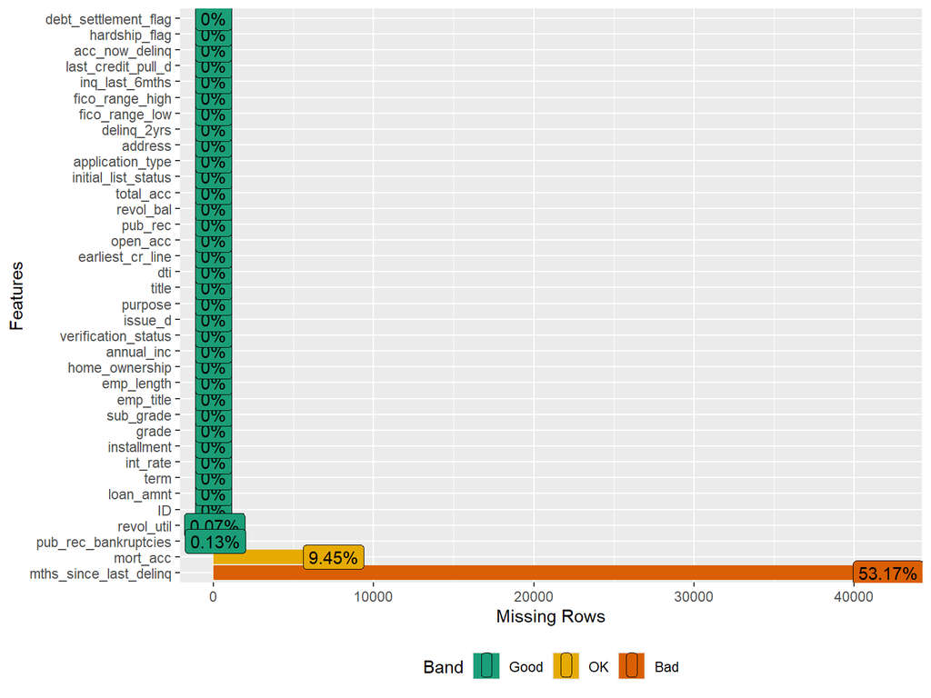

```r
plot_missing(df)
```

# Look at structure and ensure these are all factor variables

```r
str(bank_factor)
```

```
## 'data.frame':    79243 obs. of  17 variables:
##  $ term                : Factor w/ 2 levels " 36 months"," 60 months": 1 1 1 1 2 2 2 1 1 2 ...
##  $ grade               : Factor w/ 7 levels "A","B","C","D",..: 3 3 2 5 2 3 6 3 2 4 ...
##  $ sub_grade           : Factor w/ 35 levels "A1","A2","A3",..: 14 11 8 21 10 11 28 12 9 17 ...
##  $ emp_title           : Factor w/ 43586 levels "","  Credit rev specialist",..: 28879 10774 37115 32204 38448 18071 24913 2823 38743 37148 ...
##  $ emp_length          : Factor w/ 12 levels "","< 1 year",..: 4 5 4 4 4 4 11 2 5 8 ...
##  $ home_ownership      : Factor w/ 6 levels "ANY","MORTGAGE",..: 6 2 6 2 6 6 2 6 2 6 ...
##  $ verification_status : Factor w/ 3 levels "Not Verified",..: 3 2 1 2 2 2 3 2 3 2 ...
##  $ issue_d             : Factor w/ 114 levels "Apr-2008","Apr-2009",..: 93 54 25 91 64 92 8 8 82 42 ...
##  $ purpose             : Factor w/ 14 levels "car","credit_card",..: 3 3 3 3 2 2 2 3 3 10 ...
##  $ title               : Factor w/ 12237 levels "","'08 & '09 Roth IRA Investments",..: 3870 3870 8288 3870 3139 3139 3139 3870 3870 1893 ...
##  $ earliest_cr_line    : Factor w/ 618 levels "Apr-1961","Apr-1962",..: 552 245 241 293 185 552 450 549 541 547 ...
##  $ initial_list_status : Factor w/ 2 levels "f","w": 2 1 1 1 2 2 1 2 1 1 ...
##  $ application_type    : Factor w/ 3 levels "DIRECT_PAY","INDIVIDUAL",..: 2 2 2 2 2 2 2 2 2 2 ...
##  $ address             : Factor w/ 79108 levels "000 Adrian Cliffs\nRandyton, LA 22690",..: 41639 65134 66277 27304 57318 77233 25031 16448 28914 66627 ...
##  $ last_credit_pull_d  : Factor w/ 131 levels "","Apr-2009",..: 42 64 20 21 116 118 56 120 118 89 ...
##  $ hardship_flag       : Factor w/ 1 level "N": 1 1 1 1 1 1 1 1 1 1 ...
##  $ debt_settlement_flag: Factor w/ 2 levels "N","Y": 1 1 1 1 1 1 1 2 1 1 ...
```

# Histograms for numeric variables

These variables can easily be seen for their skew, symmetry, and range. If the range is large from the models, like pub_rec, revol_bal, dti, and annual_inc, this indicates outliers in the data.

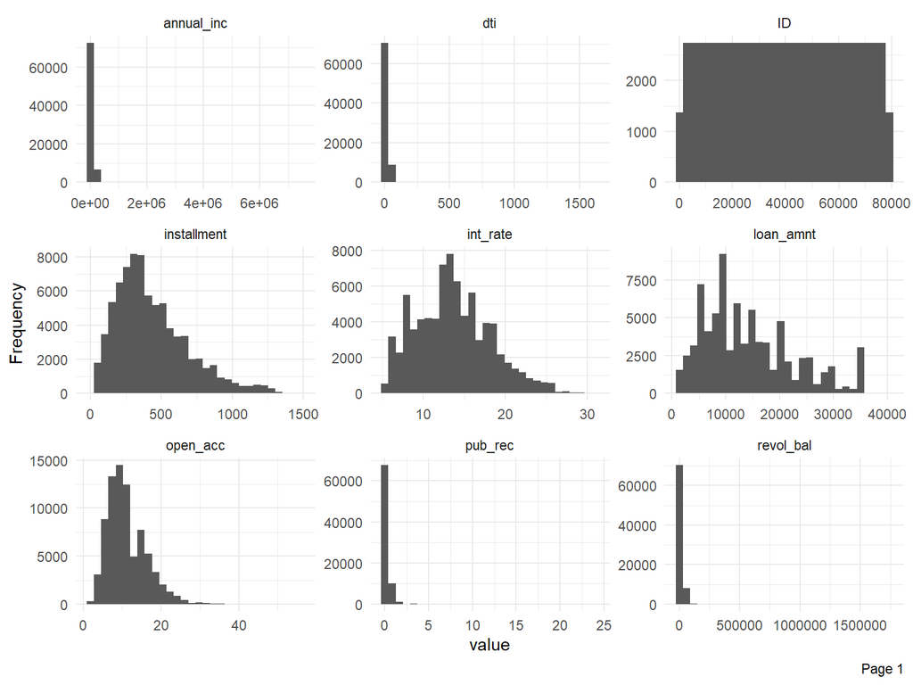

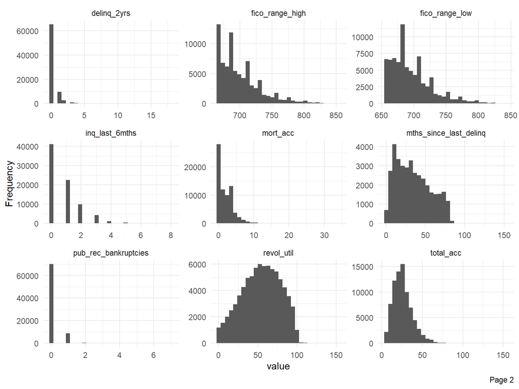

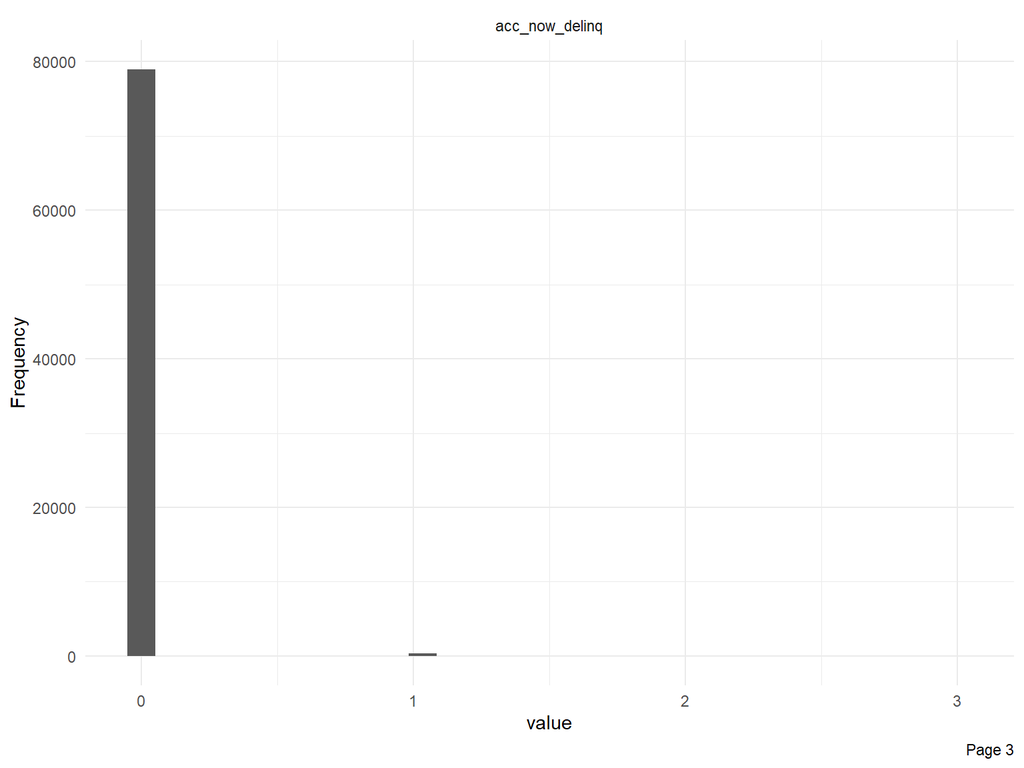

```r
DataExplorer::plot_histogram(bank_numeric,
                             ggtheme=theme_minimal(),
                             ncol=3,
                             nrow=3)
```

# Create a heat map to check correlation between variables

Based on these results, we can confirm outliers in the data and deal with them accordingly. Also, we see that these numeric variables can have correlation to one defaulting on a loan. Lets look at a heat map to finalize some of the cleaning techniques we will perform

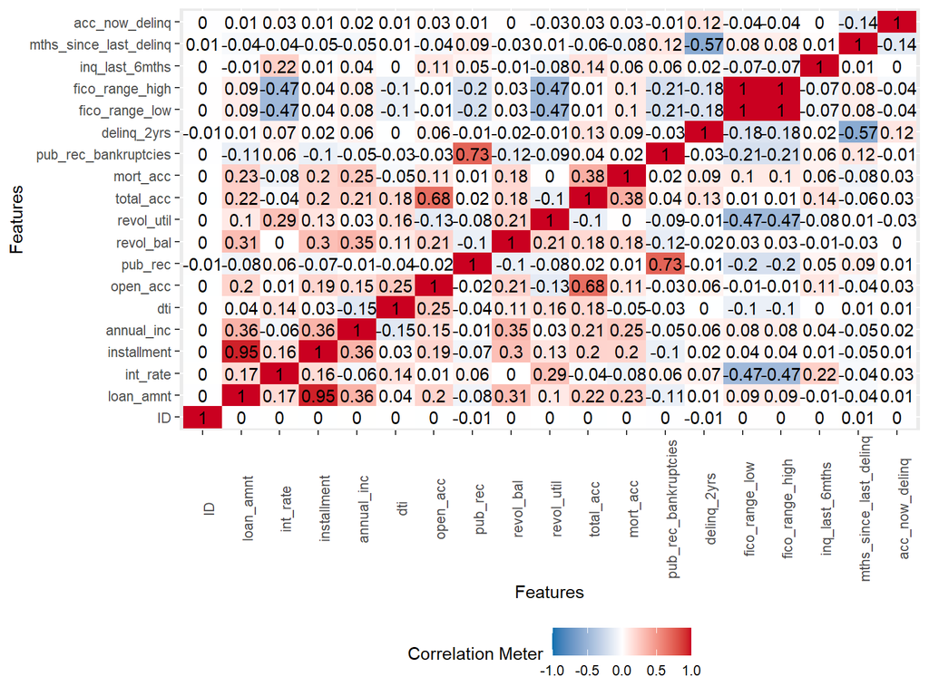

```r
DataExplorer::plot_correlation(bank_numeric,
                               type="continuous",
                               cor_args = list("use" = "pairwise.complete.obs")
                               )
```